# R 지도시각화

홍수지

2024-08-03

## 미국 주별 강력 범죄율 단계 구분도 만들기

#### 패키지 준비하기

단계 구분도는 ggiraphExtra 패키지를 이용하여 쉽게 만들수 있다. ggiraphExtra패키지를 이용하는데 필요한 mapproj 패키지를 설치 합니다.

```r
# 패키지 설치
install.packages("mapproj")
install.packages("ggiraphExtra")
```

#### 미국 주별 범죄 데이터 준비하기

```r
library(ggiraphExtra)
str(USArrests)
```

```
## 'data.frame':    50 obs. of  4 variables:
##  $ Murder  : num  13.2 10 8.1 8.8 9 7.9 3.3 5.9 15.4 17.4 ...
##  $ Assault : int  236 263 294 190 276 204 110 238 335 211 ...
##  $ UrbanPop: int  58 48 80 50 91 78 77 72 80 60 ...
##  $ Rape    : num  21.2 44.5 31 19.5 40.6 38.7 11.1 15.8 31.9 25.8 ...
```

```r
head(USArrests)
```

```
##            Murder Assault UrbanPop Rape
## Alabama      13.2     236       58 21.2
## Alaska       10.0     263       48 44.5
## Arizona       8.1     294       80 31.0
## Arkansas      8.8     190       50 19.5
## California    9.0     276       91 40.6
## Colorado      7.9     204       78 38.7
```

USArrest 데이터는 지역명 변수가 따로 없고 대신 행 이름이 지역명이 되었습니다. tibble 패키지의 rownames_to_column()을 이용해 행 이름을 state변수로 바꿔 새 데이터 프레임을 만들었습니다. 지도 데이터의 지역명 변수는 모든 값이 소문자로 되어 있기 때문에 지도 데이터와 동일하게 맞추기 위해 tolower()를 이용해 state의 값을 소문자로 수정 하였습니다.

```r
library(tibble)
crime <- rownames_to_column(USArrests, var = "state")
crime$state <-tolower(crime$state)
str(crime)
```

```
## 'data.frame':    50 obs. of  5 variables:
##  $ state   : chr  "alabama" "alaska" "arizona" "arkansas" ...
##  $ Murder  : num  13.2 10 8.1 8.8 9 7.9 3.3 5.9 15.4 17.4 ...
##  $ Assault : int  236 263 294 190 276 204 110 238 335 211 ...
##  $ UrbanPop: int  58 48 80 50 91 78 77 72 80 60 ...
##  $ Rape    : num  21.2 44.5 31 19.5 40.6 38.7 11.1 15.8 31.9 25.8 ...
```

#### 미국 주 지도 데이터 준비하기

미국 주별 위경도 데이터가 들어 있는 maps 패키지를 설치하고 ggplot2 패키지의 map_data()를 이용합니다

```r
# 미국 주 지도 데이터 준비하기
install.packages("maps")
library(ggplot2)
states_map <- map_data("state")
str(states_map)
```

```
## 'data.frame':    15537 obs. of  6 variables:
##  $ long     : num  -87.5 -87.5 -87.5 -87.5 -87.6 ...
##  $ lat      : num  30.4 30.4 30.4 30.3 30.3 ...
##  $ group    : num  1 1 1 1 1 1 1 1 1 1 ...
##  $ order    : int  1 2 3 4 5 6 7 8 9 10 ...
##  $ region   : chr  "alabama" "alabama" "alabama" "alabama" ...
##  $ subregion: chr  NA NA NA NA ...
```

#### 단계 구분도 만들기

살인 범죄 건수를 색깔로 표현하기 위해 aes의 fill에 Murder변수를 지정하고 map_id에 살인 지역 구분 기준이 되는 state 변수를 지정합니다

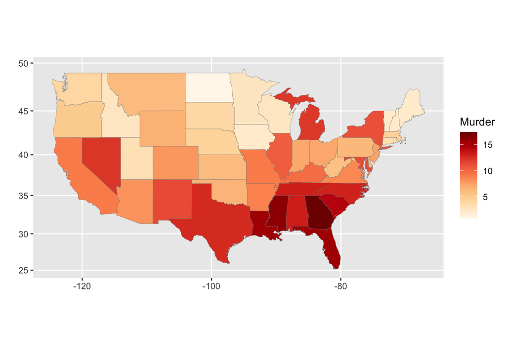

```r
# 단계 구분도 만들기
ggChoropleth(data = crime, # 지도에 표현할 데이터
             aes(fill=Murder, map_id=state), # 색깔로 표현할 변수, 지역 기준 변수
             map = states_map) #지도 데이터
```

#### 인터랙티브 단계 구분도 말들기

interactive 파라미터를 Ture로 설정하면 인터랙티브 단계구분도를 만들 수 있다.

```r
# 인터랙티브 단계 구분도 만들기
ggChoropleth(data = crime, # 지도에 표현할 데이터
             aes(fill=Murder, map_id=state), # 색깔로 표현할 변수, 지역 기준 변수
             map = states_map, #지도 데이터
             interactive = T)
```

[interactive chart not shown]

## 대한민국 시도별 인구, 결핵 환자 수 단계 구분도 만들기

#### 패키지 준비

kormaps2014 패키지를 이용하는 데 필요한 stringi 패키지를 설치 하겠습니다. 그 후 devtools 패키지를 설치 한 후 install_github()를 패키지 개발자가 깃허브에 공유한 korrmaps2014 패키지를 설지하고 로드 하겠습니다.

```r
install.packages("stringi")
install.packages("devtools")
library(devtools)
devtools::install_github("cardiomoon/kormaps2014")
library(kormaps2014)
```

#### 대한 민국 시도별 인구 데이터 준비하기

```r
str(korpop1)
```

```
## 'data.frame':    17 obs. of  25 variables:
##  $ C행정구역별_읍면동     : Factor w/ 3819 levels "'00","'03","'04",..: 5 455 681 832 995 1096 1181 1246 1264 1874 ...
##  $ 행정구역별_읍면동      : Factor w/ 3398 levels "  가경동","  가곡동",..: 3388 3387 3383 3392 3382 3384 3390 3389 3379 3378 ...
##  $ 시점                   : int  2015 2015 2015 2015 2015 2015 2015 2015 2015 2015 ...
##  $ 총인구_명              : int  9904312 3448737 2466052 2890451 1502881 1538394 1166615 204088 12479061 1518040 ...
##  $ 남자_명                : int  4859535 1701347 1228511 1455017 748867 772243 606924 103210 6309661 768241 ...
##  $ 여자_명                : int  5044777 1747390 1237541 1435434 754014 766151 559691 100878 6169400 749799 ...
##  $ 내국인_계_명           : int  9567196 3404667 2436770 2822601 1481289 1519314 1136755 199617 12026429 1499734 ...
##  $ 내국인_남자_명         : int  4694317 1675339 1211219 1414793 736656 763310 587603 100455 6039800 758601 ...
##  $ 내국인_여자_명         : int  4872879 1729328 1225551 1407808 744633 756004 549152 99162 5986629 741133 ...
##  $ 외국인_계_명           : Factor w/ 1256 levels "10","100","1009",..: 618 764 554 1024 394 330 563 772 781 306 ...
##  $ 외국인_남자_명         : Factor w/ 995 levels "10","100","1002",..: 200 388 224 589 82 952 262 413 401 985 ...
##  $ 외국인_여자_명         : Factor w/ 856 levels "10","100","1000",..: 174 189 66 350 840 8 25 173 196 812 ...
##  $ 가구_계_가구           : int  3914820 1348315 937573 1066297 573181 588395 434058 76419 4537581 611578 ...
##  $ 일반가구_가구          : int  3784490 1335900 928528 1045417 567157 582504 423412 75219 4384742 606117 ...
##  $ 집단가구_가구          : Factor w/ 176 levels "10","100","102",..: 64 143 129 148 109 104 68 139 99 155 ...
##  $ 외국인가구_가구        : Factor w/ 764 levels "10","100","10002",..: 75 46 709 214 579 574 15 35 126 523 ...
##  $ 주택_계_호             : int  2793244 1164352 738100 942244 486527 468885 357674 81130 3693557 569899 ...
##  $ 단독주택_호            : Factor w/ 2149 levels "100","1000","1001",..: 1443 1090 594 34 2019 1941 1777 606 1614 1122 ...
##  $ 아파트_호              : Factor w/ 2466 levels "10","100","10008",..: 517 2103 1622 1787 1281 1161 879 1886 873 1031 ...
##  $ 연립주택_호            : Factor w/ 875 levels "10","100","1002",..: 54 424 857 266 773 4 782 874 67 241 ...
##  $ 다세대주택_호          : Factor w/ 1428 levels "10","100","1000",..: 1192 269 1064 551 1331 803 580 251 1073 60 ...
##  $ 비거주용_건물내_주택_호: Factor w/ 534 levels "10","100","1001",..: 279 94 17 473 391 384 421 431 294 19 ...
##  $ 주택이외의_거처_호     : Factor w/ 911 levels "10","100","1007",..: 159 643 167 550 26 27 805 295 200 84 ...
##  $ C행정구역별            : chr  "11" "21" "22" "23" ...
##  $ code                   : chr  "11" "21" "22" "23" ...
```

```r
library(dplyr)
korpop1 <- rename(korpop1, pop = 총인구_명, name = `행정구역별_읍면동`)
korpop1$name <- iconv(korpop1$name, from = "UTF-8", to = "CP949")
str(kormap1)
```

```
## 'data.frame':    8831 obs. of  15 variables:
##  $ id       : chr  "0" "0" "0" "0" ...
##  $ long     : num  138 138 138 138 138 ...
##  $ lat      : num  50.7 50.7 50.7 50.7 50.7 ...
##  $ order    : int  1 2 3 4 5 6 7 8 9 10 ...
##  $ hole     : logi  FALSE FALSE FALSE FALSE FALSE FALSE ...
##  $ piece    : Factor w/ 113 levels "1","2","3","4",..: 1 1 1 1 1 1 1 1 1 1 ...
##  $ group    : Factor w/ 205 levels "0.1","1.1","1.2",..: 1 1 1 1 1 1 1 1 1 1 ...
##  $ SP_ID    : Factor w/ 17 levels "0","1","10","11",..: 1 1 1 1 1 1 1 1 1 1 ...
##  $ SIDO_CD  : Factor w/ 17 levels "11","21","22",..: 1 1 1 1 1 1 1 1 1 1 ...
##  $ SIDO_NM  : Factor w/ 17 levels "\xb0\xad\xbf\xf8\xb5\xb5",..: 9 9 9 9 9 9 9 9 9 9 ...
##  $ BASE_YEAR: Factor w/ 1 level "2014": 1 1 1 1 1 1 1 1 1 1 ...
##  $ name     : Factor w/ 17 levels "강원도","경기도",..: 9 9 9 9 9 9 9 9 9 9 ...
##  $ name1    : Factor w/ 17 levels "\xb0\xad\xbf\xf8\xb5\xb5",..: 9 9 9 9 9 9 9 9 9 9 ...
##  $ region   : Factor w/ 17 levels "11","21","22",..: 1 1 1 1 1 1 1 1 1 1 ...
##  $ code     : Factor w/ 17 levels "11","21","22",..: 1 1 1 1 1 1 1 1 1 1 ...
```

```r
# 모든 문자열 열을 UTF-8로 변환
korpop1 <- data.frame(lapply(korpop1, function(x) {
  if (is.character(x)) {
    iconv(x, from = "CP949", to = "UTF-8")
  } else {
    x
  }
}), stringsAsFactors = FALSE)
```

#### 대한민국 시도별 인구 단계 구분도 만들기

```r
ggChoropleth(data = korpop1, # 지도에 표현할 데이터
             aes(fill=pop, map_id = code, tooltip = name), #색깔로 표현할 수 변수
             map = kormap1, # 지도 데이터
             interactive=T) # 인터랙티브
```

[interactive chart not shown]

#### 대한민국 시도별 결핵 환자 수 단계 구분도 만들기

```r
# 대한 시도별 결핵 환자 수 단계 구분도 만들기

str(tbc)
```

```
## 'data.frame':    255 obs. of  5 variables:
##  $ name1 : Factor w/ 18 levels "강원","경기",..: 1 2 3 4 5 6 7 8 9 10 ...
##  $ code  : int  32 31 38 37 24 22 25 21 11 29 ...
##  $ name  : Factor w/ 17 levels "강원도","경기도",..: 1 2 3 4 5 6 7 8 9 10 ...
##  $ year  : Factor w/ 15 levels "2001","2002",..: 1 1 1 1 1 1 1 1 1 1 ...
##  $ NewPts: int  1396 4843 1749 2075 658 1406 1345 3188 11178 NA ...
```

```r
tbc$name <- iconv(tbc$name, from = "UTF-8", to = "CP949")
tbc <- data.frame(lapply(tbc, function(x) {
  if (is.character(x)) {
    iconv(x, from = "CP949", to = "UTF-8")
  } else {
    x
  }
}), stringsAsFactors = FALSE)

# 대한 민국 시도별 결핵환자 수 단계 구분도 만들기

ggChoropleth(data = tbc, # 지도에 표현할 데이터
             aes(fill=NewPts, map_id = code, tooltip = name), #색깔로 표현할 수 변수
             map = kormap1,
             interactive=T)
```

[interactive chart not shown]